# IODS course project

To get an even clearer idea of what is going on in the data, it is best to also plot the means within each group. For this, it might be useful to plot this with a new variable “weight_g” where we have the mean weight gained within each group.

```r
RATS_long$Weight_g <- NA
Weight_init <- RATS_long$Weight[which(RATS_long$Time == 1)]
for(i in levels(as.factor(RATS_long$Time))) {
  rows <- which(RATS_long$Time == as.numeric(i))
  RATS_long$Weight_g[rows] <- RATS_long$Weight[rows] - Weight_init
}

RATSL <- RATS_long %>%
  group_by(Group, Time) %>%
  summarise(mean_gain = mean(Weight_g), se = sd(Weight_g) / length(Weight_g)) %>%
  ungroup() %>%
  group_by(Group)
```

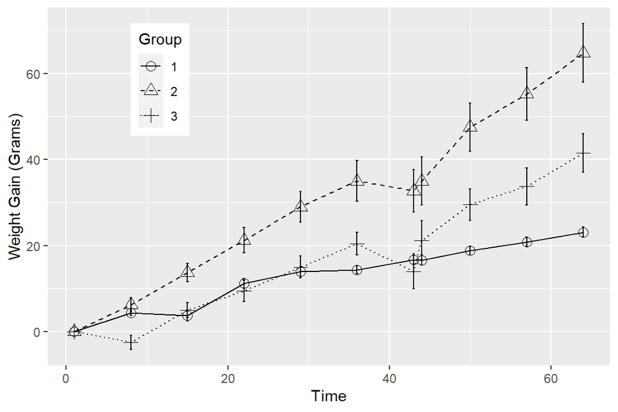

```r
# Plot the weight gain mean profiles
ggplot(RATSL, aes(x = Time, y = mean_gain, linetype = Group, shape = Group)) +
  geom_line() +
  scale_linetype_manual(values = c(1, 2, 3)) +
  geom_point(size = 3) +
  geom_errorbar(aes(ymin = mean_gain - se, ymax = mean_gain + se, linetype = "1"), width = 0.3) +
  scale_shape_manual(values = c(1, 2, 3)) +
  theme(legend.position = c(0.2, 0.8)) +
  scale_y_continuous(name = "Weight Gain (Grams)")
```

```r
  scale_x_continuous(name = "Time")
```

```
## <ScaleContinuousPosition>
##  Range:
##  Limits:    0 --    1
```

Again, our view of the data changes. Contrary to what I interpreted above, it seems that group 1 and 3 have had on average much less weight gained than in group 2 with the chunkier rats. We can further illustrate this visually by doing a simple boxplot of the average weight gained in each group.

```r
RATSL2 <- RATS_long %>%
  filter(Time == max(Time)) %>%
  group_by(Group, ID) %>%
  summarise(mean = mean(Weight_g))%>%
  ungroup()
```

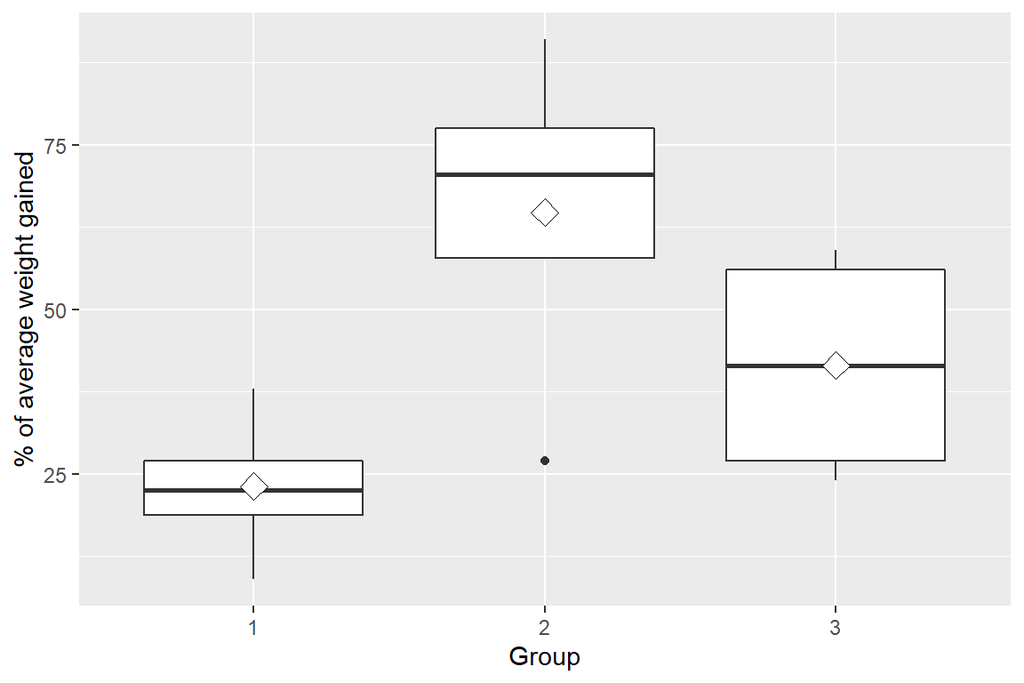

```r
# Draw a boxplot
ggplot(RATSL2, aes(x = Group, y = mean)) +
  geom_boxplot() +
  stat_summary(fun = "mean", geom = "point", shape = 23, size = 4, fill = "white") +
  scale_y_continuous(name = "% of average weight gained")
```